# Homework 03

## TidyTuesday Section (optional)

**ImportantInstructions**

You can count work on this week’s TidyTuesday toward the exceptional work required for an A in the Homework component.

Explore the week’s [TidyTuesday](https://github.com/rfordatascience/tidytuesday) challenge. Develop a research question, then answer it through a short data story with effective visualization(s). Provide sufficient background for readers to grasp your narrative.

Research Question

How is the competition schedule structured during the 2026 Winter Olympics — and are medal events concentrated at specific points in time compared to training sessions?

```r
library(tidyverse)
library(lubridate)

schedule <- read_csv(
  "https://raw.githubusercontent.com/rfordatascience/tidytuesday/main/data/2026/2026-02-10/schedule.csv"
)

schedule_clean <- schedule |>
  mutate(
    date = as.Date(date),
    start_local = ymd_hms(start_datetime_local, tz = "Europe/Rome"),
    end_local   = ymd_hms(end_datetime_local, tz = "Europe/Rome"),
    duration_min = as.numeric(difftime(end_local, start_local, units = "mins")),
    event_type = case_when(
      is_training ~ "Training",
      is_medal_event ~ "Medal Event",
      TRUE ~ "Non-Medal Competition"
    )
  )
```

The following plot shows:

Medal events increase in frequency toward the middle and final days.

The final days feature a high concentration of medal events.

This suggests intentional pacing — building excitement toward the closing ceremony.

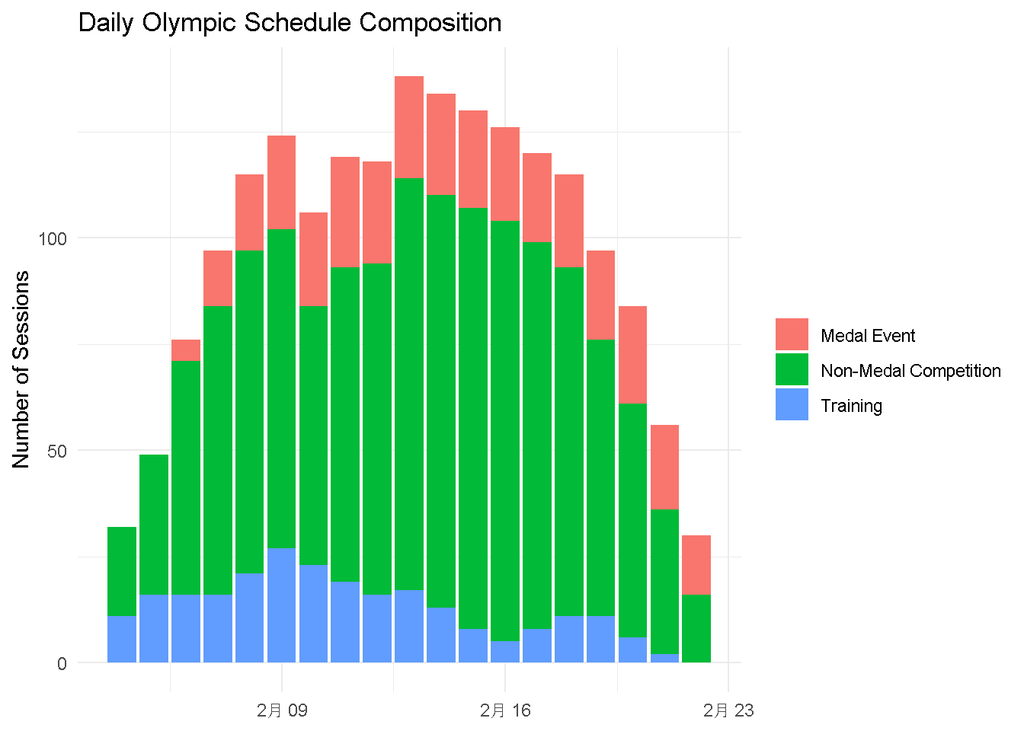

```r
schedule_clean |>
  count(date, event_type) |>
  ggplot(aes(x = date, y = n, fill = event_type)) +
  geom_col() +
  labs(
    title = "Daily Olympic Schedule Composition",
    x = NULL,
    y = "Number of Sessions",
    fill = NULL
  ) +
  theme_minimal()
```

Some disciplines require many sessions (e.g., hockey, skiing events), while others have fewer but longer events.

This reflects structural differences in sport format:

Tournament-based sports → many sessions

Single-final sports → fewer sessions

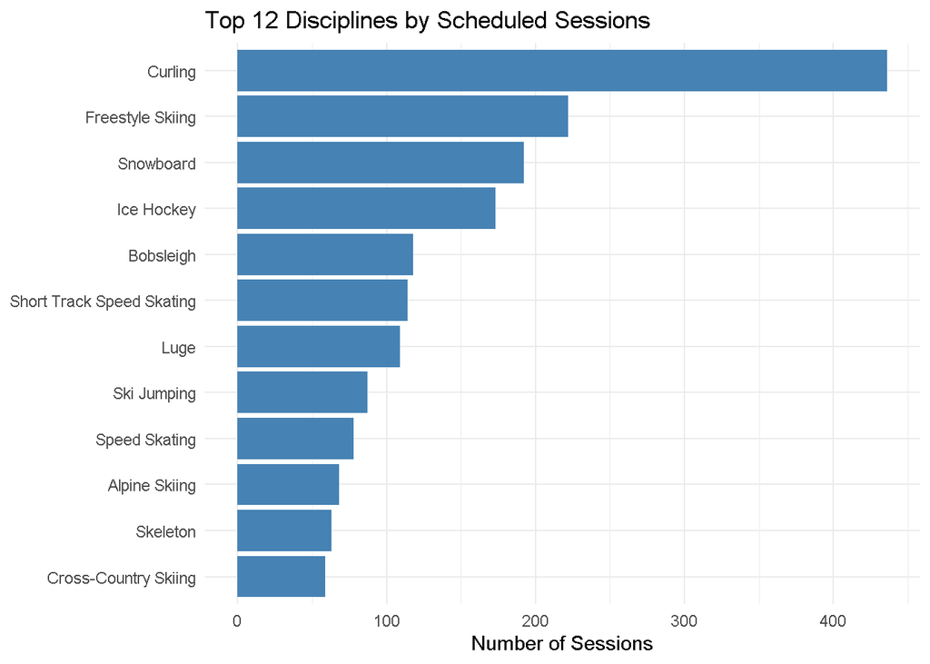

```r
schedule_clean |>
  count(discipline_name, sort = TRUE) |>
  slice_max(n, n = 12) |>
  ggplot(aes(x = reorder(discipline_name, n), y = n)) +
  geom_col(fill = "steelblue") +
  coord_flip() +
  labs(
    title = "Top 12 Disciplines by Scheduled Sessions",
    x = NULL,
    y = "Number of Sessions"
  ) +
  theme_minimal()
```

A few venues host a disproportionate share of events. These become logistical hubs and likely media focal points.

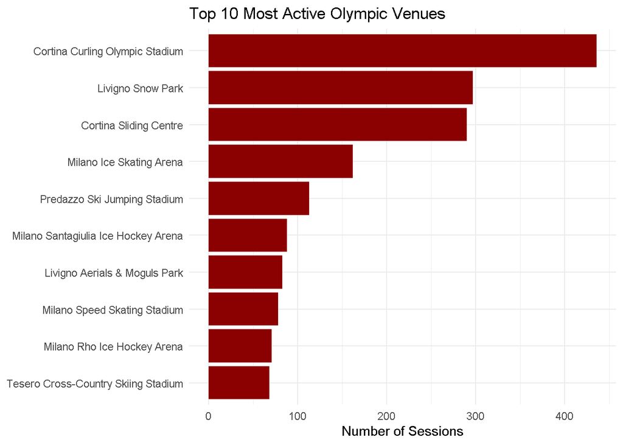

```r
schedule_clean |>
  count(venue_name, sort = TRUE) |>
  slice_max(n, n = 10) |>
  ggplot(aes(x = reorder(venue_name, n), y = n)) +
  geom_col(fill = "darkred") +
  coord_flip() +
  labs(
    title = "Top 10 Most Active Olympic Venues",
    x = NULL,
    y = "Number of Sessions"
  ) +
  theme_minimal()
```

Some sports (e.g., hockey) show longer session times. Others (e.g., sprint events) are short but numerous.

This affects:

Broadcast scheduling

Athlete fatigue

Venue turnover logistics

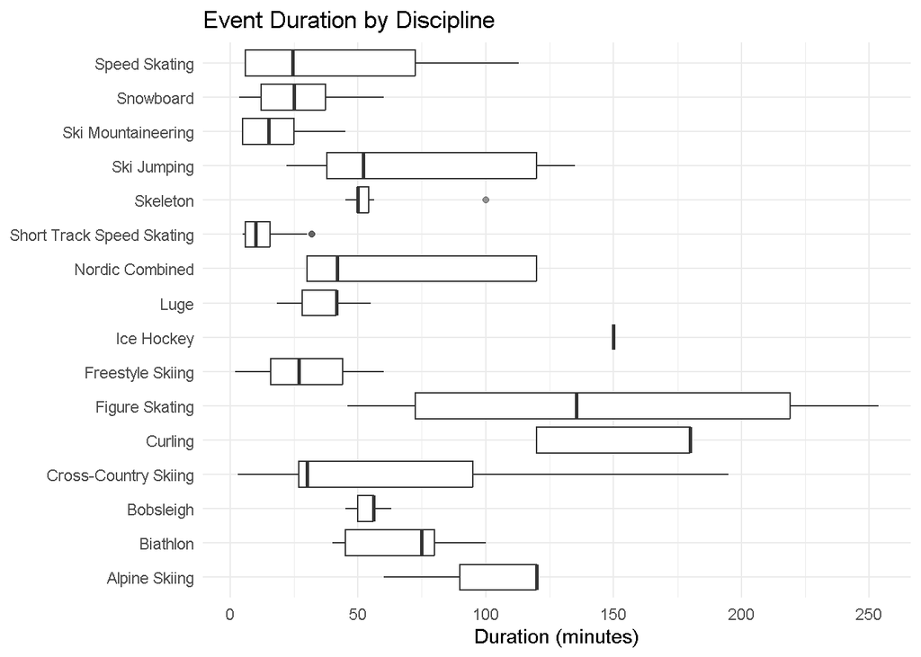

```r
schedule_clean |>
  filter(!is.na(duration_min),
         duration_min > 0,
         duration_min < 8 * 60) |>
  ggplot(aes(x = discipline_name, y = duration_min)) +
  geom_boxplot(outlier.alpha = 0.2) +
  coord_flip() +
  labs(
    title = "Event Duration by Discipline",
    x = NULL,
    y = "Duration (minutes)"
  ) +
  theme_minimal()
```

Overall Findings

Medal events are strategically concentrated, increasing toward the final days.

A small number of disciplines and venues dominate total activity.

Event duration varies widely across sports, reflecting fundamental differences in competition structure.